### Practical Machine Learning Course Project

### December 21, 2015

### Exploratory Data Analysis

Because all of the remaining variables were numeric, I was thinking that I might try to use a more straightforward algorithm such as “glm”. So my first inclination was to look for “bad” data, or highly correlated data, and eliminate it.

Nine of the variables had more than five data points that were greater than four standard deviations from the mean, and at first I considered leaving these variables out of the analysis.

```r
library(reshape2)
training.scale <- scale(training[,8:59])
training.scale[abs(training.scale) <= 4] <- 0
training.scale[abs(training.scale) > 4] <- 1
outliers <- colSums(training.scale)
outliers <- melt(outliers)
subset(outliers, value >  5)
```

```
##                  value
## gyros_belt_x        60
## gyros_belt_y       114
## gyros_belt_z       160
## magnet_belt_x       57
## magnet_belt_y      222
## magnet_belt_z       63
## gyros_arm_z         12
## gyros_dumbbell_y    10
## gyros_forearm_x     22
```

Even with over 19,000 observations, these nine variables had more outliers than expected. Maybe they should go? I also was thinking that I might want to do principal component analysis, and for that I might need to transform the data to make it look more like a normal distribution. For this, I made a Q-Q plots like these for the variables **total_accel_arm** and **roll_belt**, respectively.

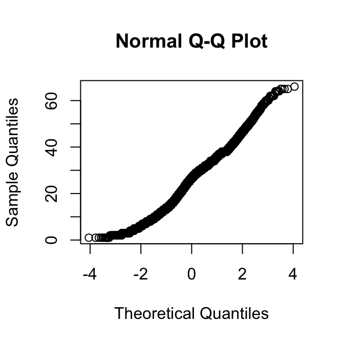

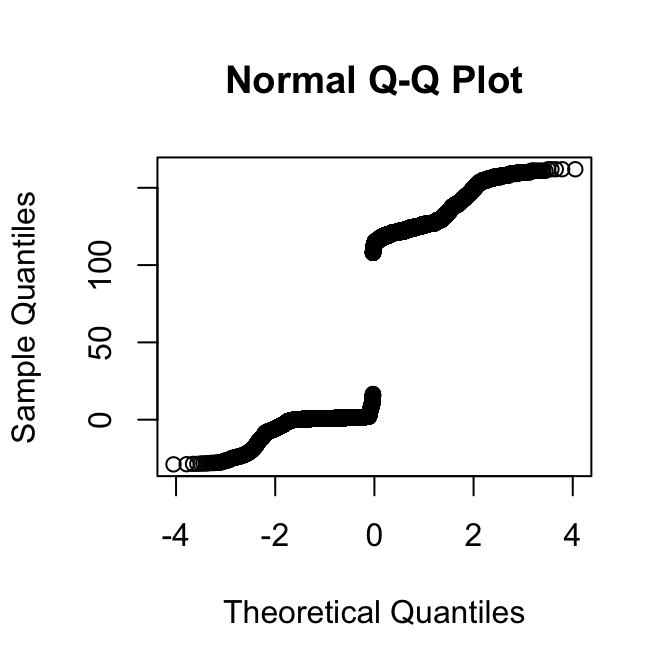

Hmm…not really what I expected. The data for the variable **total_accel_arm** does generally follow the diagonal and looks normally distributed, but the **roll_belt** data is very jaggedy. Wait, maybe each jagged part of the plot is associated with a different **classe**? I made some additional plots of the **roll_belt** data, by **classe**, shown below:

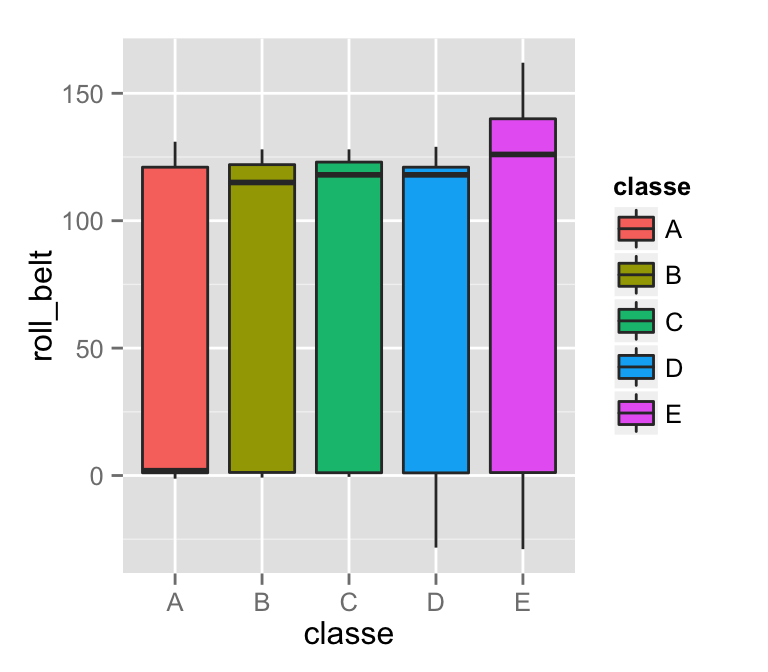

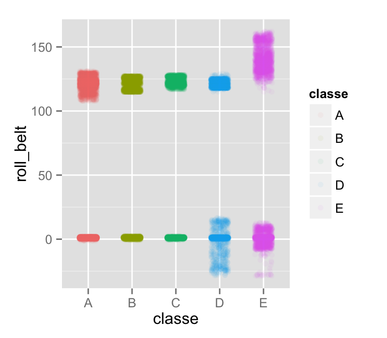

```r
library(ggplot2)
par(mar=c(4,4,.1,.1),cex.lab=.95,cex.axis=.9,mgp=c(2,.7,0),tcl=-.3)
ggplot(training, aes(x=classe, y = roll_belt, fill=classe))+geom_boxplot()
ggplot(training, aes(x=classe, y = roll_belt, color=classe))+geom_point(position=position_jitter(width=0.2), alpha=0.05)
```

I looked at scatterplots for most of the variables. Variables with **_belt** in their name seemed to distinguish categories D & E from A, B, and C. Variables with **_arm** distinguished A. **_dumbell** seemed to differentiate C, B and A from the others. And **_forearm** seemed to differentiate A. These were just general impressions from looking at the patterns.

I made a correlation matrix, and there were numerous highly positively correlated variables, but as a first try, I did not eliminate any of the variables, even the ones with the extreme outliers (the outliers seemed to be associated with one class, which could help for classification). I decided to try the “gbm” and “rf” algorithms, because they seemed best suited for this type of data. I chose not to do principal component analysis.

### Building and testing prediction models.

First, I randomly partitioned the training set into validation, testing and training sets.

```r
dim(validation)
```

```
## [1] 5885   60
```

```r
dim(train.set)
```

```
## [1] 9619   60
```

```r
dim(test.set)
```

```
## [1] 4118   60
```

I used the train.set to build a model using the random forest algorithm (“rf”) in the caret package.

```r
# Build a "rf" model. Do not use formula interface (takes much longer).
library(caret)
predictors <- names(train.set[, 8:59])

set.seed(569)
rf.mod <- train(y=train.set$classe, x=train.set[,predictors], method="rf", data=train.set, trControl=trainControl(method="cv"), number=3)
rf.mod$finalModel
```

```
##
## Call:
##  randomForest(x = x, y = y, mtry = param$mtry, data = ..1, number = 3)
##                Type of random forest: classification
##                      Number of trees: 500
## No. of variables tried at each split: 27
##
##         OOB estimate of  error rate: 1.1%
## Confusion matrix:
##      A    B    C    D    E class.error
## A 2729    3    2    0    1 0.002193784
## B   24 1822   14    1    0 0.020956475
## C    0   10 1657   11    0 0.012514899
## D    0    3   24 1547    3 0.019023462
## E    0    1    3    6 1758 0.005656109
```

To get an unbiased estimate of the accuracy, I used this model to predict classes on the test.set data I set aside previously. Then I made a confusionMatrix to compare the predicted classes to the known classes in the test.set.

```r
set.seed(700)
rf.pred <- predict(rf.mod, newdata=test.set)
confusionMatrix(rf.pred, test.set$classe)
```

```
## Confusion Matrix and Statistics
##
##           Reference
## Prediction    A    B    C    D    E
##          A 1169    8    0    0    0
##          B    1  784    3    1    0
##          C    1    4  711   17    0
##          D    0    1    4  656    1
##          E    0    0    0    1  756
##
## Overall Statistics
##
##                Accuracy : 0.9898
##                  95% CI : (0.9862, 0.9926)
##     No Information Rate : 0.2844
##     P-Value [Acc > NIR] : < 2.2e-16
##
##                   Kappa : 0.9871
##  Mcnemar's Test P-Value : NA
##
## Statistics by Class:
##
##                      Class: A Class: B Class: C Class: D Class: E
## Sensitivity            0.9983   0.9837   0.9903   0.9719   0.9987
## Specificity            0.9973   0.9985   0.9935   0.9983   0.9997
## Pos Pred Value         0.9932   0.9937   0.9700   0.9909   0.9987
## Neg Pred Value         0.9993   0.9961   0.9979   0.9945   0.9997
## Prevalence             0.2844   0.1935   0.1744   0.1639   0.1838
## Detection Rate         0.2839   0.1904   0.1727   0.1593   0.1836
## Detection Prevalence   0.2858   0.1916   0.1780   0.1608   0.1838
## Balanced Accuracy      0.9978   0.9911   0.9919   0.9851   0.9992
```

It appears that the accuracy on the test.set (98.98%) is quite similar to the accuracy on the training.set (98.9%). There are other things that I could do to attempt to improve this model, but I honestly do not think that it is worth it. I am open to your suggestions. I did use the “gbm” algorithm on the same data set. It was 96.77% accurate on the test.set, with the parameters I used. I have a lot to learn about the parameters. I also considered eliminating some of the variables (both models ranked variables, and there appeared to be 7-15 variables which were relatively unimportant). However, given the accuracy of this model, I think I am going to stop here. I didn’t really even need to use the validation set I made.

Happy Holidays!